# Laboratorium 9

Aleksander Jóźwik

Link do repozytorium: [GitHub](https://github.com/OlaszPL/fft-ocr)

#### Import wykorzystanych bibliotek i funkcji

```python
import numpy as np
import matplotlib.pyplot as plt
import matplotlib.patches as patches
from PIL import Image, ImageOps
from IPython.display import display
from scipy.ndimage import label, find_objects
```

## Zadanie 1. Analiza obrazów

W tym zadaniu przeprowadzimy analizę obrazów przy pomocy Dyskretnej Transformaty Fouriera (DFT), a konkretnie jej szybkiej implementacji w postaci Fast Fourier Transform (FFT).

Poszczególnymi etapami będą:

1. Analiza obrazu w domenie częstotliwościowej.
2. Wyszukiwanie wzorców przy pomocy korelacji wyznaczanej poprzez twierdzenie o splocie.

## Twierdzenie o splocie

Niech $\mathbf{a} \times \mathbf{b}$ oznacza iloczyn element po elemencie: $$ \mathbf{a} \times \mathbf{b} = \begin{pmatrix} \alpha_0 \\ \alpha_1 \\ \vdots \\ \alpha_{n-1} \end{pmatrix} \times \begin{pmatrix} \beta_0 \\ \beta_1 \\ \vdots \\ \beta_{n-1} \end{pmatrix} = \begin{pmatrix} \alpha_0 \beta_0 \\ \alpha_1 \beta_1 \\ \vdots \\ \alpha_{n-1} \beta_{n-1} \end{pmatrix}_{n \times 1} $$

Niech $\hat{\mathbf{a}}$ i $\hat{\mathbf{b}}$ będą wektorami dopełnionymi zerami: $$ \hat{\mathbf{a}} = \begin{pmatrix} \alpha_0 \\ \vdots \\ \alpha_{n-1} \\ 0 \\ \vdots \\ 0 \end{pmatrix}_{2n \times 1} \qquad \hat{\mathbf{b}} = \begin{pmatrix} \beta_0 \\ \vdots \\ \beta_{n-1} \\ 0 \\ \vdots \\ 0 \end{pmatrix}_{2n \times 1} $$

Jeśli $\mathbf{F} = \mathbf{F}_{2n}$ jest macierzą Fouriera rzędu $2n$, to: $$ \mathbf{F}(\mathbf{a} \odot \mathbf{b}) = (\mathbf{F} \hat{\mathbf{a}}) \times (\mathbf{F} \hat{\mathbf{b}}) $$

oraz $$ \mathbf{a} \odot \mathbf{b} = \mathbf{F}^{-1} \left[ (\mathbf{F} \hat{\mathbf{a}}) \times (\mathbf{F} \hat{\mathbf{b}}) \right] $$

Zgodnie z twierdzeniem o splocie, splot dwóch wektorów o wymiarach $n \times 1$ można obliczyć wykonując trzy dyskretne transformaty Fouriera.

Wykonanie splotu zgodnie z definicją wymaga $n^2$ mnożeń skalarnych, jednakże wykorzystanie FFT pozwala zredukować tę złożonosć do ok. $3 n logn$ mnożeń. Wykorzystamy ten fakt do szybkiego wyznaczenia korelacji.

Wzór na korelację wzajemną można zapisać jako:

$$ C = \mathcal{F}^{-1} \left( \mathcal{F}(A) \cdot \overline{\mathcal{F}(B)} \right) $$

gdzie:

- $A$ to pierwszy sygnał (np. obraz),
- $B$ to drugi sygnał (np. wzorzec, tutaj obrócony o $180^\circ$),
- $\mathcal{F}$ oznacza transformatę Fouriera,
- $\overline{\mathcal{F}(B)}$ to sprzężenie zespolone transformaty Fouriera $B$,
- $\mathcal{F}^{-1}$ to odwrotna transformata Fouriera,
- $\cdot$ oznacza mnożenie element po elemencie.

Zgodnie z twierdzeniem o splotach, splot (i korelację) można obliczyć jako odwrotną transformatę Fouriera iloczynu transformat Fouriera odpowiednio przygotowanych sygnałów. W przypadku korelacji wzajemnej, jeden z sygnałów (wzorzec) należy obrócić o $180^\circ$, co odpowiada sprzężeniu zespolonemu w dziedzinie Fouriera. Dzięki temu zamiast kosztownego obliczania splotu/korelacji w dziedzinie czasu/przestrzeni, można wykonać szybkie operacje w dziedzinie częstotliwości, co znacząco przyspiesza obliczenia dla dużych danych.

Wczytywanie obrazów w skali szarości przedstawiających tekst oraz ławicę ryb.

```python
text = Image.open("data/images/galia.png").convert("L")
fish = Image.open("data/images/school.jpg").convert("L")
```

### Analiza obrazu z tekstem będącym fragmentem pamiętnika "O wojnie galijskiej" Juliusza Cezara

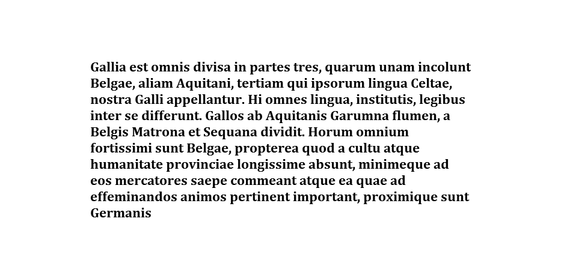

```python
display(text)
```

Odwrócenie kolorów (czarne tło)

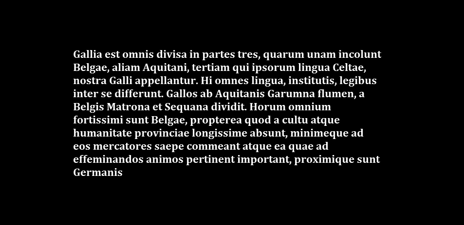

```python
text = ImageOps.invert(text)
display(text)
```

Konwersja obrazu do postaci macierzowej

```python
text_arr = np.array(text)
```

#### Przekształcenie do domeny częstotliwościowej i przedstawienie wartości fazy oraz modułu współczynników Fouriera

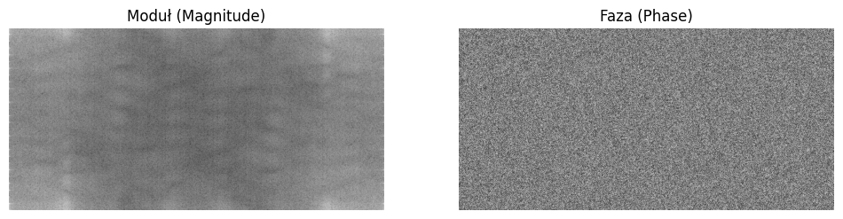

```python
a = np.fft.fft2(text_arr)

magnitude = np.abs(a)
phase = np.angle(a)

plt.figure(figsize=(12, 5))
plt.subplot(1, 2, 1)
plt.title("Moduł (Magnitude)")
plt.imshow(np.log1p(magnitude), cmap='gray')
plt.axis('off')

plt.subplot(1, 2, 2)
plt.title("Faza (Phase)")
plt.imshow(phase, cmap='gray')
plt.axis('off')

plt.show()
```

Wczytanie w skali szarości przykładowego reprezentanta grupy - litery `e` oraz odwrócenie jego kolorów

```python
e_letter = Image.open("data/images/galia_e.png").convert("L")
e_letter = ImageOps.invert(e_letter)
display(e_letter)

e_letter_arr = np.array(e_letter)
```

[output not shown]

Obliczenie korelacji między wybranym wzorcem, a całym obrazem przy pomocy transformacji Fouriera

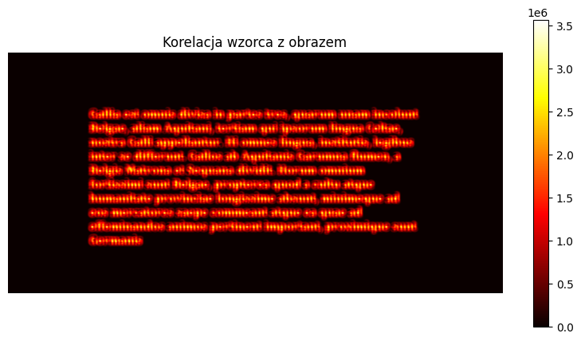

```python
# Dopasowanie rozmiaru wzorca do obrazu przez rotację i padding
pattern = np.rot90(e_letter_arr, 2)
h, w = text_arr.shape
ph, pw = pattern.shape

# Padding wzorca do rozmiaru obrazu
pattern_padded = np.zeros_like(text_arr)
pattern_padded[:ph, :pw] = pattern

# Obliczenie korelacji przez transformatę Fouriera
corr = np.fft.ifft2(np.fft.fft2(text_arr) * np.fft.fft2(pattern_padded)) # wzór z konspektu
corr_real = np.real(corr)

plt.figure(figsize=(10, 5))
plt.title("Korelacja wzorca z obrazem")
plt.imshow(corr_real, cmap='hot')
plt.colorbar()
plt.axis('off')
plt.show()
```

Przestrzeń korelacji w 3D - piki oznaczają dopasowania

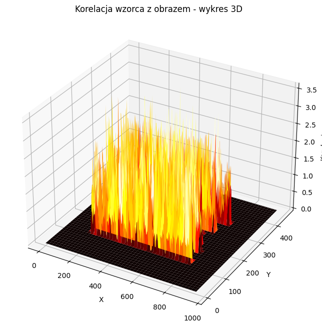

```python
X = np.arange(corr_real.shape[1])
Y = np.arange(corr_real.shape[0])
X, Y = np.meshgrid(X, Y)

fig = plt.figure(figsize=(12, 8))
ax = fig.add_subplot(111, projection='3d')
ax.plot_surface(X, Y, corr_real, cmap='hot', edgecolor='none')
ax.set_title("Korelacja wzorca z obrazem - wykres 3D")
ax.set_xlabel('X')
ax.set_ylabel('Y')
ax.set_zlabel('Korelacja')
plt.show()
```

Wykrywanie wystąpień wzorca przy pomocy progu dla maksymalnej wartości korelacji. W tym przypadku przyjęto `0.95` co zapewniło odpowiednią skuteczność. Pod obrazem umieszczono informację o liczbie wystąpień wzorca.

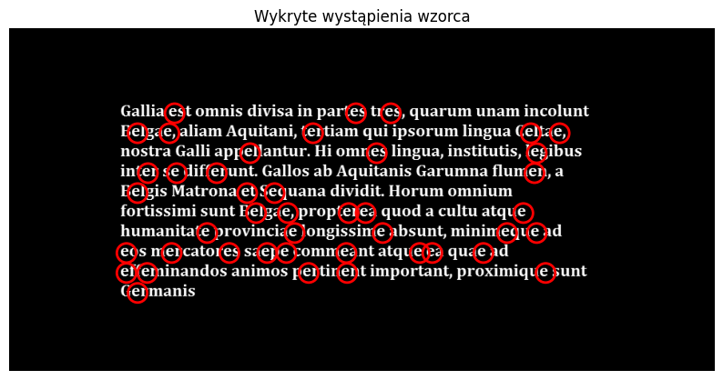

```
Liczba wystąpień wzorca: 43
```

```python
# 1. Znajdź lokalne maksima (prosty threshold)
threshold = np.max(corr_real) * 0.95  # PRÓG 0.95
maxima = (corr_real > threshold)
labeled, num_features = label(maxima)
slices = find_objects(labeled)

# 2. Wyświetl oryginalny obraz z nałożonymi okręgami
fig, ax = plt.subplots(figsize=(10, 10))
ax.imshow(np.array(text), cmap='gray')
for dy, dx in slices:
    y = (dy.start + dy.stop) // 2
    x = (dx.start + dx.stop) // 2
    circle = patches.Circle((x - 4, y - 5), radius=max(ph, pw), edgecolor='red', facecolor='none', lw=2)
    ax.add_patch(circle)
plt.title("Wykryte wystąpienia wzorca")
plt.axis('off')
plt.show()

print("Liczba wystąpień wzorca:", num_features)
```

### Analiza obrazu przedstawiającego ławicę ryb

Dla poniższego obrazu wykonano takie same czynności co w przypadku tekstu powyżej. Jedyną różnicą jest zrezygnowanie z odwrócenia kolorów, które w tym przypadku pogarszało skuteczność wyszukiwania wzorca.

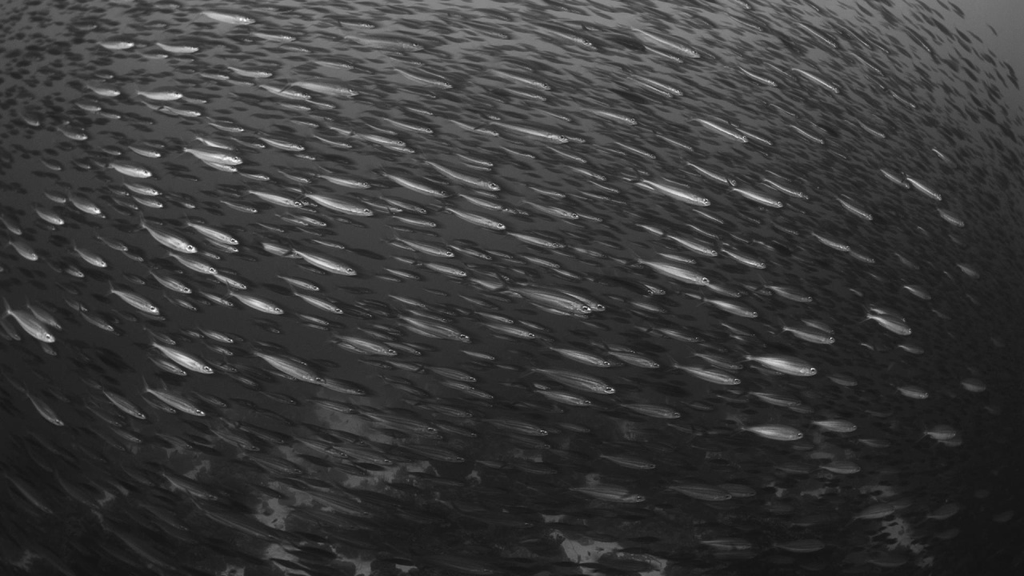

```python
display(fish)
```

```python
fish_arr = np.array(fish)
```

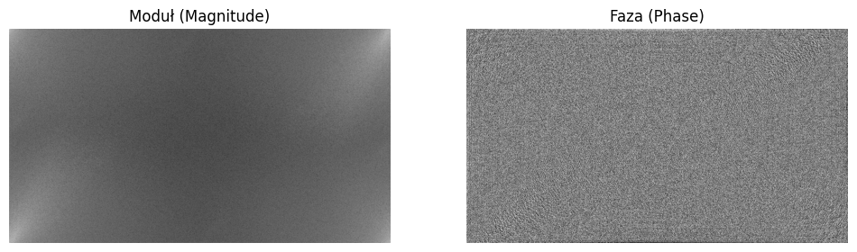

```python
a = np.fft.fft2(fish_arr)

magnitude = np.abs(a)
phase = np.angle(a)

plt.figure(figsize=(12, 5))
plt.subplot(1, 2, 1)
plt.title("Moduł (Magnitude)")
plt.imshow(np.log1p(magnitude), cmap='gray')
plt.axis('off')

plt.subplot(1, 2, 2)
plt.title("Faza (Phase)")
plt.imshow(phase, cmap='gray')
plt.axis('off')

plt.show()
```

Jako wzorzec wczytano w skali szarości fragment jednej z ryb

```python
one_fish = Image.open("data/images/fish1.png").convert("L")
display(one_fish)

one_fish_arr = np.array(one_fish)
```

[output not shown]

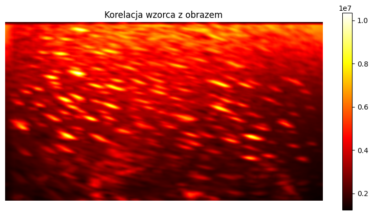

```python
# Dopasowanie rozmiaru wzorca do obrazu przez rotację i padding
pattern = np.rot90(one_fish_arr, 2)
h, w = fish_arr.shape
ph, pw = pattern.shape

# Padding wzorca do rozmiaru obrazu
pattern_padded = np.zeros_like(fish_arr)
pattern_padded[:ph, :pw] = pattern

# Obliczenie korelacji przez transformatę Fouriera
corr = np.fft.ifft2(np.fft.fft2(fish_arr) * np.fft.fft2(pattern_padded)) # wzór z konspektu
corr_real = np.real(corr)

plt.figure(figsize=(10, 5))
plt.title("Korelacja wzorca z obrazem")
plt.imshow(corr_real, cmap='hot')
plt.colorbar()
plt.axis('off')
plt.show()
```

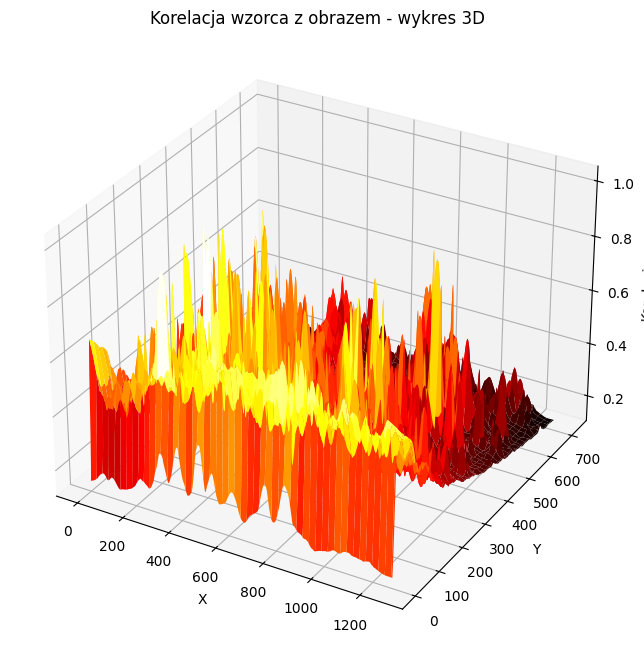

```python
X = np.arange(corr_real.shape[1])
Y = np.arange(corr_real.shape[0])
X, Y = np.meshgrid(X, Y)

fig = plt.figure(figsize=(12, 8))
ax = fig.add_subplot(111, projection='3d')
ax.plot_surface(X, Y, corr_real, cmap='hot', edgecolor='none')
ax.set_title("Korelacja wzorca z obrazem - wykres 3D")
ax.set_xlabel('X')
ax.set_ylabel('Y')
ax.set_zlabel('Korelacja')
plt.show()
```

Dla tego obrazu jako próg dla maksymalnej wartości korelacji przyjęto `0.5`

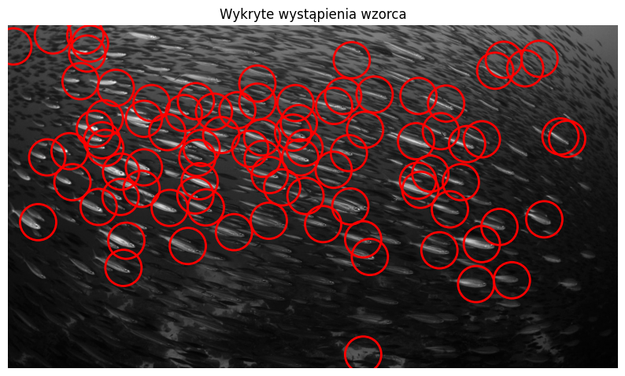

```
Liczba wystąpień wzorca: 87
```

```python
# 1. Znajdź lokalne maksima (prosty threshold)
threshold = np.max(corr_real) * 0.5
maxima = (corr_real > threshold)
labeled, num_features = label(maxima)
slices = find_objects(labeled)

# 2. Wyświetl oryginalny obraz z nałożonymi okręgami
fig, ax = plt.subplots(figsize=(10, 10))
ax.imshow(np.array(fish), cmap='gray')
for dy, dx in slices:
    y = (dy.start + dy.stop) // 2
    x = (dx.start + dx.stop) // 2
    # Możesz dodać offset do środka, np. y+5, x+5 jeśli trzeba
    circle = patches.Circle((x - 4, y - 5), radius=max(ph, pw), edgecolor='red', facecolor='none', lw=2)
    ax.add_patch(circle)
plt.title("Wykryte wystąpienia wzorca")
plt.axis('off')
plt.show()

print("Liczba wystąpień wzorca:", num_features)
```

## Wnioski

| **Cecha** | **Obraz tekstowy** | **Obraz mgławicy Ryb** |
| --- | --- | --- |
| **Moduł (Magnitude)** | Wyraźna, strukturalna charakterystyka — widać pasma i powtarzalne wzory odpowiadające układowi liter oraz ich ukierunkowanym krawędziom. | Gładki, rozproszony — pojaśnienia przy rogach oraz rozmyte struktury, bez wyraźnych pasm. |
| **Faza (Phase)** | Złożony, niepozorny wzór — wygląda jak losowy szum, ale zawiera kluczowe informacje o rozmieszczeniu liter i szczegółów. | Również wygląda jak losowy szum, ale odpowiada za rozmieszczenie drobnych struktur mgławicy w przestrzeni obrazu. |

1. **Twierdzenie o splocie**  
   Twierdzenie o splocie pozwala na obliczenie korelacji wzajemnej poprzez operacje w domenie częstotliwościowej. Zastosowanie FFT redukuje złożoność obliczeniową z $O(n^2)$ do $O(n \log n)$, co jest kluczowe dla analizy dużych obrazów.
2. **Efektywność metody**  
   Metoda działa skutecznie zarówno dla obrazów tekstowych, jak i bardziej złożonych, takich jak ławica ryb. W przypadku tekstu odwrócenie kolorów poprawiło wyniki, natomiast dla obrazu ryb odwrócenie kolorów było niepotrzebne, a nawet pogarszało skuteczność.
3. **Dobór progu korelacji**  
   Dobór odpowiedniego progu dla maksymalnej wartości korelacji jest kluczowy dla skutecznego wykrywania wzorców. W przypadku tekstu próg (0.95) zapewnił wysoką skuteczność, natomiast dla obrazu ryb próg (0.5) był bardziej odpowiedni ze względu na różnice w strukturze obrazu.
4. **Wykrywanie wzorców**  
   Metoda pozwala na skuteczne wykrywanie wzorców w obrazach, co zostało potwierdzone przez wizualizację wyników w postaci okręgów nałożonych na oryginalne obrazy. Wykryte lokalizacje wzorców są zgodne z oczekiwaniami.